# Data Science Assignment

## Lab assignment

In this week’s lab you will make a reproducible open science document that demonstrates your own data analysis and geovisualization.

We are also going to learn about two new packages that might be helpful for your data science approach. We will learn about the `library(viridis)`, which provides color palettes that are interpretable for visually impaired.

### The color scale

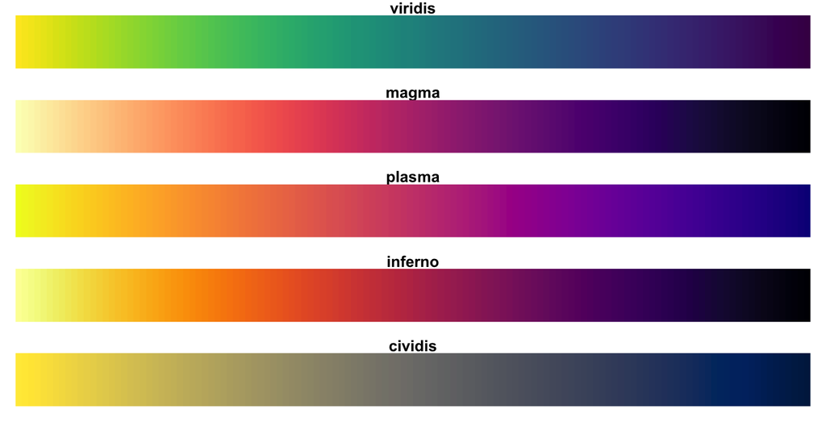

```r
library(sf)
library(ggspatial)
library(viridis)
```

```r
library(ggplot2)
## the function gives the hexadecimal colors
## the interger give the numbers of colors
magma(10)
```

```
##  [1] "#000004FF" "#180F3EFF" "#451077FF" "#721F81FF" "#9F2F7FFF" "#CD4071FF"
##  [7] "#F1605DFF" "#FD9567FF" "#FEC98DFF" "#FCFDBFFF"
```

```r
boulder <- st_read("C:/Users/dbvanber/Box/Labs/Adv_Week_1/BoulderSocialMedia.shp")
```

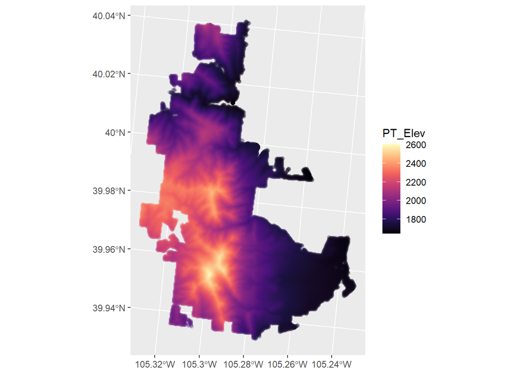

```r
ggplot() +
    geom_sf(data = boulder, aes(color=PT_Elev),
    fill = NA, alpha = .2) +
    scale_colour_gradientn(colours = magma(10))
```

We can also plot discrete values.

```r
summary(boulder$DB)
```

```
##    Length     Class      Mode
##     55519 character character
```

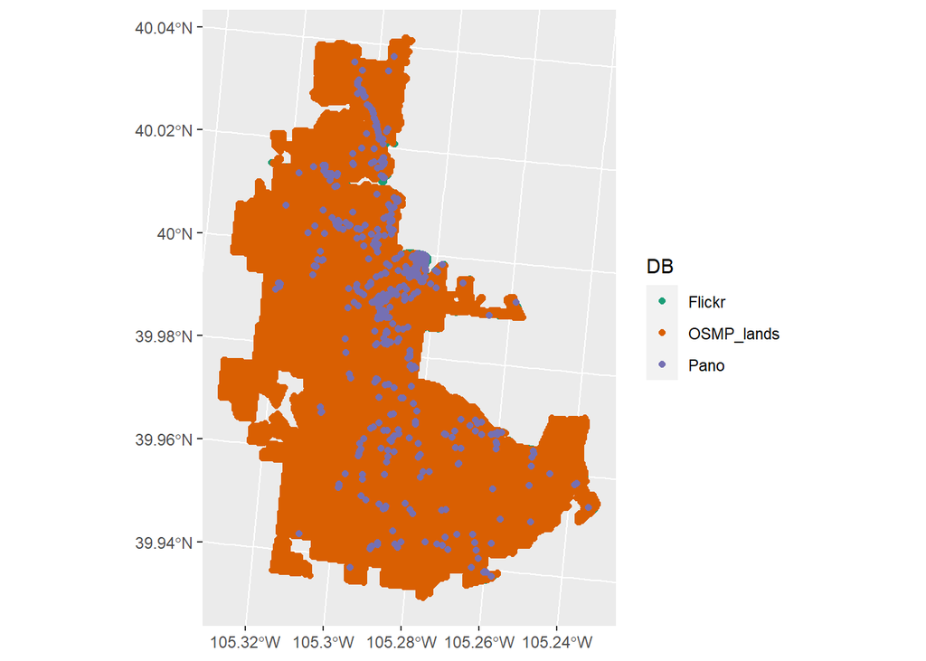

```r
p <- ggplot() +
  annotation_spatial(boulder) +
  layer_spatial(boulder, aes(col = DB))
p + scale_color_brewer(palette = "Dark2")
```

### Base maps

Now I want to grab a base map. We are going to use the package `OpenStreetMap`. You can also use “osm”, “stamen-toner”, “stamen-terrain”,“stamen-watercolor”, “esri”,“esri-topo”.

```
## Zoom: 11
```

```
## Fetching 4 missing tiles
```

```
## ...complete!
```

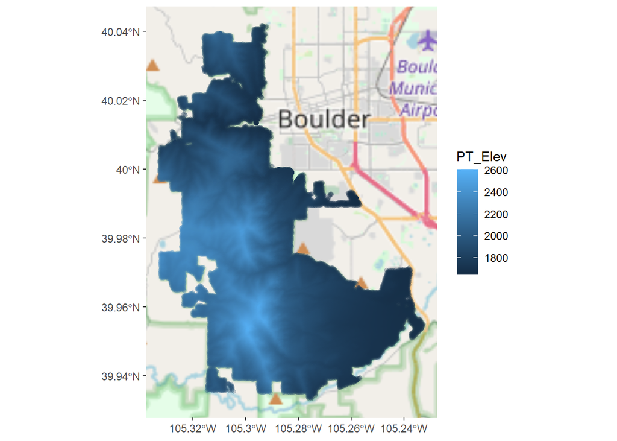

```r
ggplot() +
  annotation_map_tile(type = "osm") +
  layer_spatial(boulder, aes(col = PT_Elev),
                  fill = NA, alpha = .2)
```

There are different option for the base maps. Use these URLs to download and change the base map.

| Layer | xyz web URL |
| --- | --- |
| OpenStreetMap (Standard tile layer) | `https://a.tile.openstreetmap.org/${z}/${x}/${y}.png` OR |
|  | `https://b.tile.openstreetmap.org/${z}/${x}/${y}.png` OR |
|  | `https://c.tile.openstreetmap.org/${z}/${x}/${y}.png` |
| Wikimedia Maps | `https://maps.wikimedia.org/osm-intl/${z}/${x}/${y}.png` |
| OpenCycleMap | `http://a.tile.opencyclemap.org/cycle/${z}/${x}/${y}.png` OR |
|  | `http://b.tile.opencyclemap.org/cycle/${z}/${x}/${y}.png` |
| Humanitarian map style | `http://a.tile.openstreetmap.fr/hot/${z}/${x}/${y}.png` OR |
|  | `http://b.tile.openstreetmap.fr/hot/${z}/${x}/${y}.png` |
| OSM France | `http://a.tile.openstreetmap.fr/osmfr/${z}/${x}/${y}.png` OR |
|  | `http://b.tile.openstreetmap.fr/osmfr/${z}/${x}/${y}.png` OR |
|  | `http://c.tile.openstreetmap.fr/osmfr/${z}/${x}/${y}.png` |
| OpenSkiMap | `http://tiles.skimap.org/openskimap/${z}/${x}/${y}.png` |
| OpenSeaMap | `http://tiles.openseamap.org/seamark/${z}/${x}/${y}.png` |
| waymarkedtrails | `https://tile.waymarkedtrails.org/hiking/${z}/${x}/${y}.png` |
| Cycling routes | `https://tile.waymarkedtrails.org/cycling/${z}/${x}/${y}.png` |
| Hike & Bike | `http://toolserver.org/tiles/hikebike/${z}/${x}/${y}.png` |
| Hillshading | `http://c.tiles.wmflabs.org/hillshading/${z}/${x}/${y}.png` |
| OSM B&W | `https://tiles.wmflabs.org/bw-mapnik/${z}/${x}/${y}.png` OR |
|  | `https://a.tiles.wmflabs.org/bw-mapnik/${z}/${x}/${y}.png` OR |
|  | `https://b.tiles.wmflabs.org/bw-mapnik/${z}/${x}/${y}.png` OR |
|  | `https://c.tiles.wmflabs.org/bw-mapnik/${z}/${x}/${y}.png` |
| OSM no labels | `https://tiles.wmflabs.org/osm-no-labels/${z}/${x}/${y}.png` OR |
|  | `https://a.tiles.wmflabs.org/osm-no-labels/${z}/${x}/${y}.png` OR |
|  | `https://b.tiles.wmflabs.org/osm-no-labels/${z}/${x}/${y}.png` OR |
|  | `https://c.tiles.wmflabs.org/osm-no-labels/${z}/${x}/${y}.png` |
| Stamen Toner | `http://a.tile.stamen.com/toner/${z}/${x}/${y}.png` |
| Stamen Watercolor | `http://c.tile.stamen.com/watercolor/${z}/${x}/${y}.jpg` |
| Transport Map | `http://a.tile2.opencyclemap.org/transport/${z}/${x}/${y}.png` OR |
|  | `http://b.tile2.opencyclemap.org/transport/${z}/${x}/${y}.png` |
| Thunderforest Landscape | `http://a.tile.thunderforest.com/landscape/${z}/${x}/${y}.png` OR |
|  | `http://b.tile.thunderforest.com/landscape/${z}/${x}/${y}.png` OR |
|  | `http://c.tile.thunderforest.com/landscape/${z}/${x}/${y}.png` |
| Thunderforest Outdoors | `http://a.tile.thunderforest.com/outdoors/${z}/${x}/${y}.png` OR |
|  | `http://b.tile.thunderforest.com/outdoors/${z}/${x}/${y}.png` OR |
|  | `http://c.tile.thunderforest.com/outdoors/${z}/${x}/${y}.png` |
| pnvkarte | `http://toolserver.org/~cmarqu/hill/${z}/${x}/${y}.png` |
| OpenPtMap | `http://www.openptmap.org/tiles/${z}/${x}/${y}.png` |
| CartoLight (Positron) | `https://cartodb-basemaps-{s}.global.ssl.fastly.net/light_all/{z}/{x}/{y}.png` |
| CartoDark (Dark Matter) | `https://cartodb-basemaps-{s}.global.ssl.fastly.net/dark_all/{z}/{x}/{y}.png` |
| OpenRailwayMap | `http://a.tiles.openrailwaymap.org/standard/${z}/${x}/${y}.png` OR |
|  | `http://b.tiles.openrailwaymap.org/standard/${z}/${x}/${y}.png` OR |
|  | `http://c.tiles.openrailwaymap.org/standard/${z}/${x}/${y}.png` |

For example, if you want to use OpenStreet Map without labels:

```
## Zoom: 11
```

```
## Fetching 4 missing tiles
```

```
## ...complete!
```

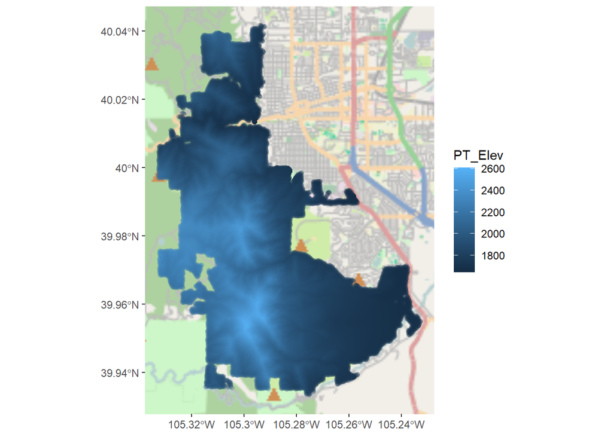

```r
ggplot() +
  annotation_map_tile(type = "https://a.tiles.wmflabs.org/osm-no-labels/${z}/${x}/${y}.png") +
  layer_spatial(boulder, aes(col = PT_Elev),
                  fill = NA, alpha = .2)
```

## Assignment

In this week’s lab, you will make an open science markdown that documents your process of data analysis and geovisualization. We will be using git to aid in version control for the code. Your assignment is to use Knitr to develop a markdown document that shows your analysis of the Boulder data (you can also use your own data if you wish). Demonstrate how you did your analysis giving step-by-step instructions with the accompanying code. Include 1 chart and 1 map. Structure and explain your analysis with text, headings, highlights, images and other markdown basics.

### Questions

1. What are the benefits and challenges of an open data science approach? Give an example based on this week’s reading. (1-2 paragraphs)
2. Include a screen grab of the history of your git commits. What is your strategy for using git? (1 paragraph)
3. Include the markdown documenting your analysis.

Here are the evluation criteria for the geovisualizations. Questions will be worth 30% of your grade, while the geovisualization and explation will be worth 70%.

| Evaluation | *Highly well-done* | *Well-done* | *Some deficiencies* | *Several deficiencies* |
| --- | --- | --- | --- | --- |
| **Cartographic principles** - 20% (title, name, date, north arrow, scale, legend, explanation symbols) | Elements present and correctly portrayed (100%) | Most elements present and correctly portrayed (99-80%) | Some elements (when appropriate) present and correctly portrayed (79-50%) | Minimal information (<50%) |
| **Presentation and Legibility** - 20% (readable, consistency and ease of understanding, flow of ideas consistent with cognition, clear explanation of content) | Highly legible, consistent and easy to understand (100%) | Mostly legible, consistent and easy to understand (99 -80%) | Somewhat legible, consistent and easy to understand (79-50%) | Minimally legible, consistent and poorly understandable (<50%) |
| **Content** - 20% (relevant, coherent and interesting topic, appropriate subject matter given the presented information/data, free of bias and error ) | Highly relevant coherent, and interesting; consistent information free of bias and error (100%) | Mostly relevant coherent, and interesting; consistent information free of bias and error (99 -80%) | Somewhat relevant coherent, and interesting; some inconsistencies in information(79-50%) | Minimally relevant coherent, and interesting; inconsistencies in information (<50%) |
| **Aesthetics** - 20% (is the map attractive, are there objective elements that are popularly viewed as beautiful) | Highly attractive/ beautiful (100%) | Mostly attractive/ beautiful (99 -80%) | Somewhat attractive/beautiful (79-50%) | Minimally attractive beautiful (<50%) |
| **Creativity and persuasiveness** - 20% (imaginative information/data, convincing argumentation, presence of sustainability principles) | Highly imaginative; convincing of sustainability principles (100%) | Mostly imaginative; convincing of sustainability principles (99 -80%) | Somewhat imaginative; less convincing of sustainability principles (79-50%) | Minimally imaginative; not convincing of sustainability principles (<50%) |